# Packet 9 - Numerical Inference Lightning Round

Todd CadwalladerOlsker

*Last updated:* 2022-04-28

## Test for Inference on Numeric Variables

We’ll start by loading up some data from the GSS:

```r
num_vars <- c("age", "coninc", "hrs1")
cat_vars <- c("sex", "satfin", "class", "wrkstat")
my_vars <- c(num_vars, cat_vars)

gss18 <- gss_get_yr(2018)
```

```
## Fetching: https://gss.norc.org/documents/stata/2018_stata.zip
```

```r
gss_data <- gss18
gss_data <- gss_data %>%
  select(all_of(my_vars)) %>%
  mutate(
    across(everything(), haven::zap_missing),
    across(all_of(cat_vars), forcats::as_factor)
  ) %>%
  mutate(
    across(all_of(num_vars), as.numeric)
  ) ## GGS numeric variables don't play nicely with infer.
```

The `hrs1` variable records how many hours the respondent worked in the previous week.

Let’s examine the data before doing anything else:

```r
gss_data %>%
  drop_na(hrs1) %>%
  summarize(mean = mean(hrs1),
            sd = sd(hrs1),
            median = median(hrs1)
            )
```

```
## # A tibble: 1 × 3
##    mean    sd median
##   <dbl> <dbl>  <dbl>
## 1  41.3  14.5     40
```

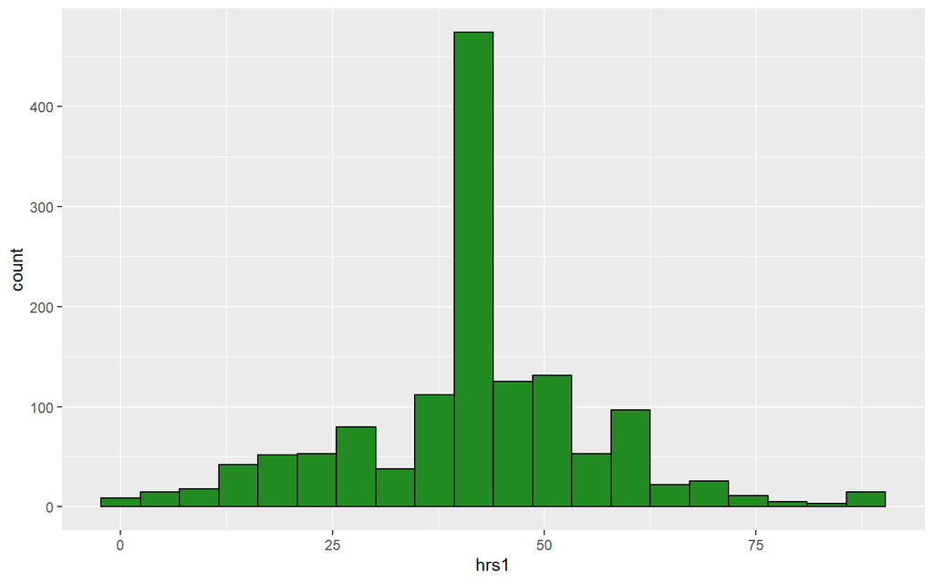

```r
gss_data %>% ggplot(aes(x = hrs1)) +
  geom_histogram(color = "black",
                 fill = "forestgreen",
                 bins = 20)
```

Let’s find the mean for our sample:

```r
x_bar <- gss_data %>%
  specify(response = hrs1) %>%
  calculate(stat = "mean")
x_bar
```

```
## Response: hrs1 (numeric)
## # A tibble: 1 × 1
##    stat
##   <dbl>
## 1  41.3
```

We can bootstrap a confidence interval for a range estimate:

```r
boot_dist <- gss_data %>%
  specify(response = hrs1) %>%
  generate(reps = 10000, type = "bootstrap") %>%
  calculate(stat = "mean")

percentile_ci <- get_ci(boot_dist, level = 0.95)
percentile_ci
```

```
## # A tibble: 1 × 2
##   lower_ci upper_ci
##      <dbl>    <dbl>
## 1     40.5     42.0
```

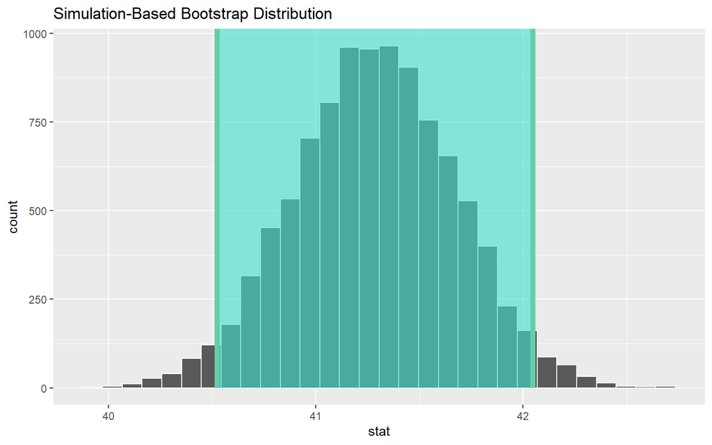

```r
boot_dist %>% visualize(bins = 30) +
  shade_confidence_interval(endpoints = percentile_ci)
```

Let’s test the claim that the average American works more than 40 hours per week. That is, we are testing the null hypothesis that $\mu = 40$ and the alternative that $\mu > 40$. We’ll do this by again bootstrapping our data, to estimate the variance.

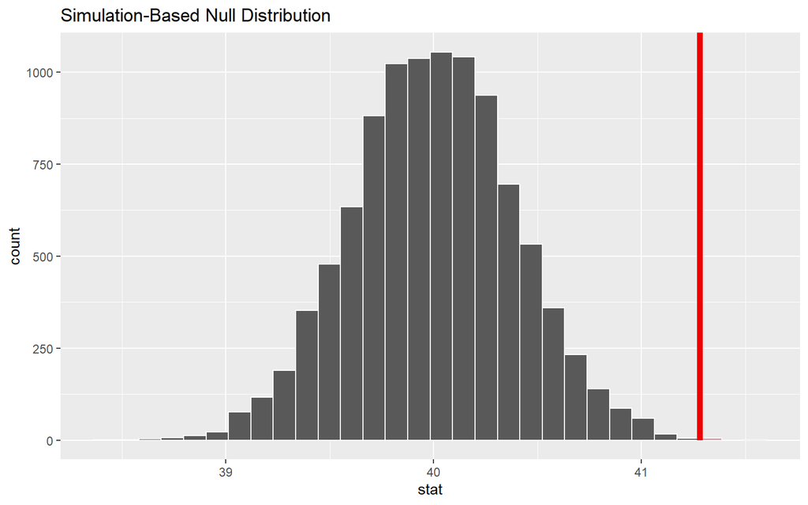

```r
null_dist <- gss_data %>%
  specify(response = hrs1) %>%
  hypothesize(null = "point", mu = 40) %>%
  generate(reps = 10000, type = "bootstrap") %>%
  calculate(stat = "mean")

null_dist %>% visualize(bins = 30) +
  shade_p_value(obs_stat = x_bar, direction = "greater")
```

```r
null_dist %>%
  get_p_value(obs_stat = x_bar, direction = "greater")
```

```
## # A tibble: 1 × 1
##   p_value
##     <dbl>
## 1  0.0006
```

The “theoretical distribution” for a sample mean is the *t-statistic*. The idea is that we can’t directly compute the z-score, since we don’t know the standard deviation $\sigma$. Instead, we can only approximate the standard error with $s$, the sample standard deviation:

$$SE = \frac{\sigma}{\sqrt{n}} \approx \frac{s}{\sqrt{n}}$$

The t-score is calculated the same as a z-score:

$$t = \frac{\bar{x}-\mu}{SE}$$

Because the SE is calculated with $s$ rather than $\sigma$, there is a bit more variability in the t-distribution compared to the normal (z-) distribution. In other words, the t-distribution has a slightly lower peak and slightly fatter tails than the normal distribution. (See Introduction to Modern Statistics, p. 362.) The more data we have, the more degrees of freedom in the t-distribution, and the more the t-distribution resembles a normal curve.

We can have `infer` calculate a t-statistic, and compute a null distribution based on t as well:

```r
t <- gss_data %>%
  specify(response = hrs1) %>%
  calculate(stat = "t", mu = 40)
t
```

```
## Response: hrs1 (numeric)
## # A tibble: 1 × 1
##    stat
##   <dbl>
## 1  3.29
```

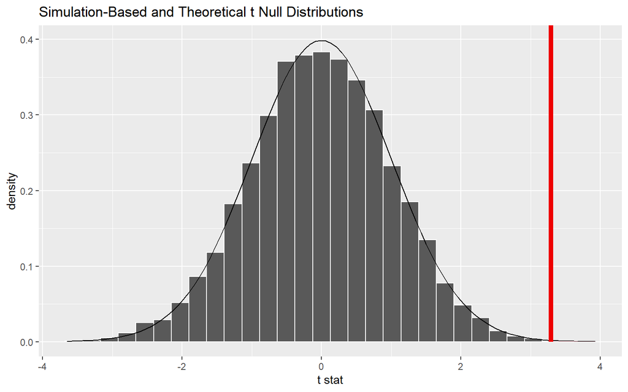

```r
null_dist <- gss_data %>%
  specify(response = hrs1) %>%
  hypothesize(null = "point", mu = 40) %>%
  generate(reps = 10000, type = "bootstrap") %>%
  calculate(stat = "t")

null_dist %>% visualize(method = "both", bins = 30) +
  shade_p_value(obs_stat = t, direction = "greater")
```

```r
null_dist %>%
  get_p_value(obs_stat = t, direction = "greater")
```

```
## # A tibble: 1 × 1
##   p_value
##     <dbl>
## 1  0.0004
```

The theoretical t-test can also be run with an R function:

```r
ttest1 <- t.test(gss_data$hrs1, mu = 40, alternative = "greater")
ttest1
```

```
##
##  One Sample t-test
##
## data:  gss_data$hrs1
## t = 3.2892, df = 1380, p-value = 0.000515
## alternative hypothesis: true mean is greater than 40
## 95 percent confidence interval:
##  40.64032      Inf
## sample estimates:
## mean of x
##  41.28168
```

```r
ttest2 <- gss_data %>%
  t_test(hrs1 ~ NULL, alternative = "greater")
ttest2
```

```
## # A tibble: 1 × 7
##   statistic  t_df p_value alternative estimate lower_ci upper_ci
##       <dbl> <dbl>   <dbl> <chr>          <dbl>    <dbl>    <dbl>
## 1      106.  1380       0 greater         41.3     40.6      Inf
```

As an aside, we can also test hypotheses involving the median. This is especially useful with highly skewed data. We don’t have a “t-distribution” for the median, but we can still perform a randomization test:

```r
x_tilde <- gss_data %>%
  specify(response = hrs1) %>%
  calculate(stat = "median")
x_tilde
```

```
## Response: hrs1 (numeric)
## # A tibble: 1 × 1
##    stat
##   <dbl>
## 1    40
```

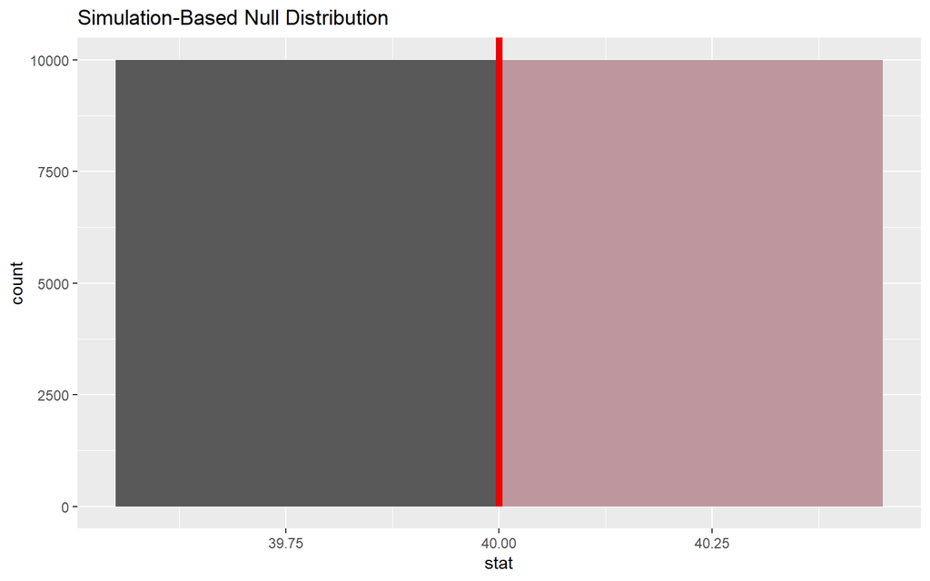

```r
null_dist <- gss_data %>%
  specify(response = hrs1) %>%
  hypothesize(null = "point", med = 40) %>%
  generate(reps = 10000, type = "bootstrap") %>%
  calculate(stat = "median")

null_dist %>% visualize(bins = 30) +
  shade_p_value(obs_stat = x_tilde, direction = "greater")
```

```r
null_dist %>%
  get_p_value(obs_stat = x_tilde, direction = "greater")
```

```
## # A tibble: 1 × 1
##   p_value
##     <dbl>
## 1       1
```

What do you notice/wonder about our results?

## Wildly non-normal data

Let’s do the same thing with the `poker` dataset from the OpenIntro package:

```r
library(openintro)
help("poker")
glimpse(poker)
```

The `winnings` variable indicates the amount of money won by a professional poker player on 50 randomply chosen days.

Let’s examine the data before doing anything else:

```r
poker %>%
  drop_na(winnings) %>%
  summarize(mean = mean(winnings),
            sd = sd(winnings),
            median = median(winnings)
            )
```

```
## # A tibble: 1 × 3
##    mean    sd median
##   <dbl> <dbl>  <dbl>
## 1  90.1  704.     11
```

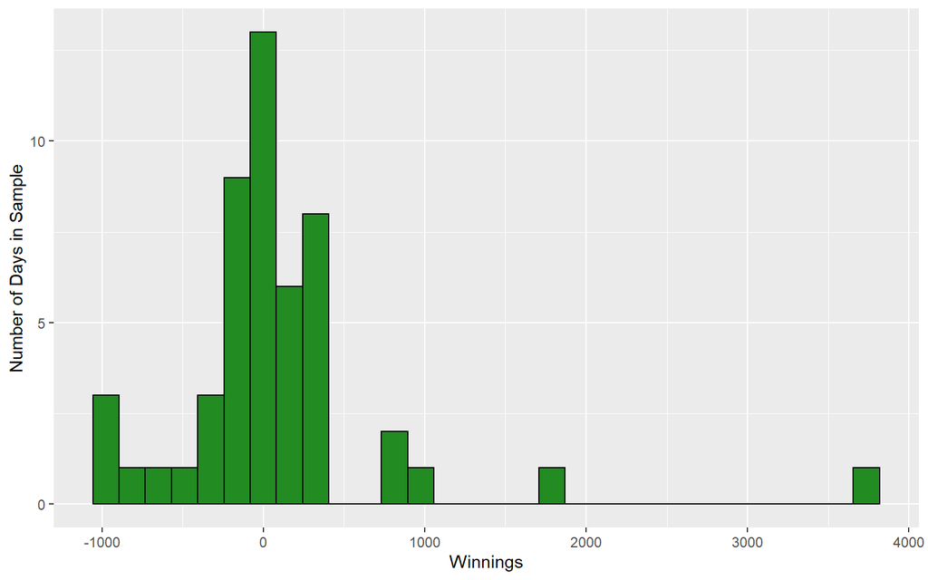

```r
poker %>% ggplot(aes(x = winnings)) +
  geom_histogram(color = "black",
                 fill = "forestgreen",
                 bins = 30) +
  labs(
    x = "Winnings",
    y = "Number of Days in Sample"
  )
```

Let’s find the mean for our sample:

```r
x_bar <- poker %>%
  specify(response = winnings) %>%
  calculate(stat = "mean")
x_bar
```

```
## Response: winnings (numeric)
## # A tibble: 1 × 1
##    stat
##   <dbl>
## 1  90.1
```

We can bootstrap a confidence interval for a range estimate:

```r
boot_dist <- poker %>%
  specify(response = winnings) %>%
  generate(reps = 10000, type = "bootstrap") %>%
  calculate(stat = "mean")

percentile_ci <- get_ci(boot_dist)
percentile_ci
```

```
## # A tibble: 1 × 2
##   lower_ci upper_ci
##      <dbl>    <dbl>
## 1    -84.3     303.
```

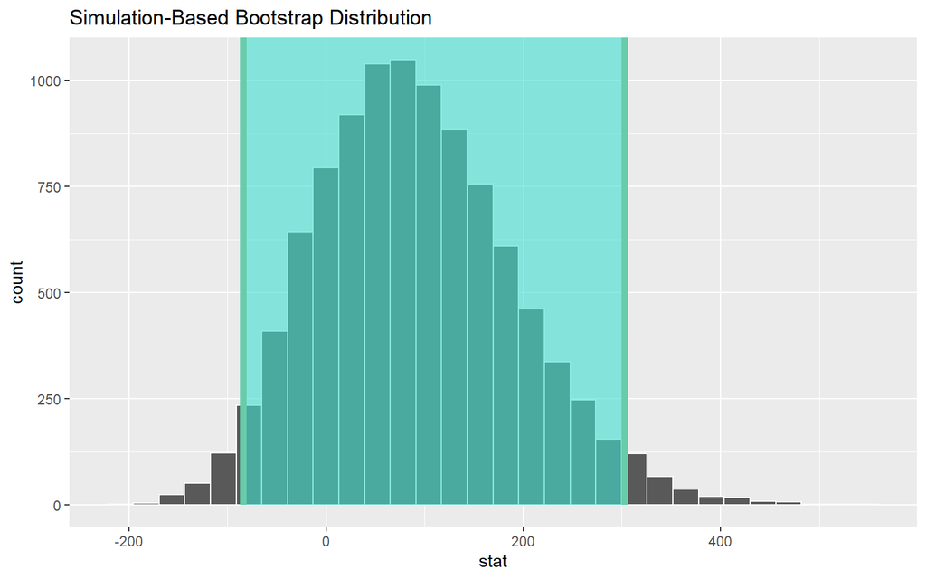

```r
boot_dist %>% visualize(bins = 30) +
  shade_confidence_interval(endpoints = percentile_ci)
```

Let’s test the claim that the average winnings are over $0 (that is, the professional poker player is actually making money!). That is, we are testing the null hypothesis that $\mu = 0$ and the alternative that $\mu > 0$. We’ll do this by again bootstrapping our data, to estimate the variance.

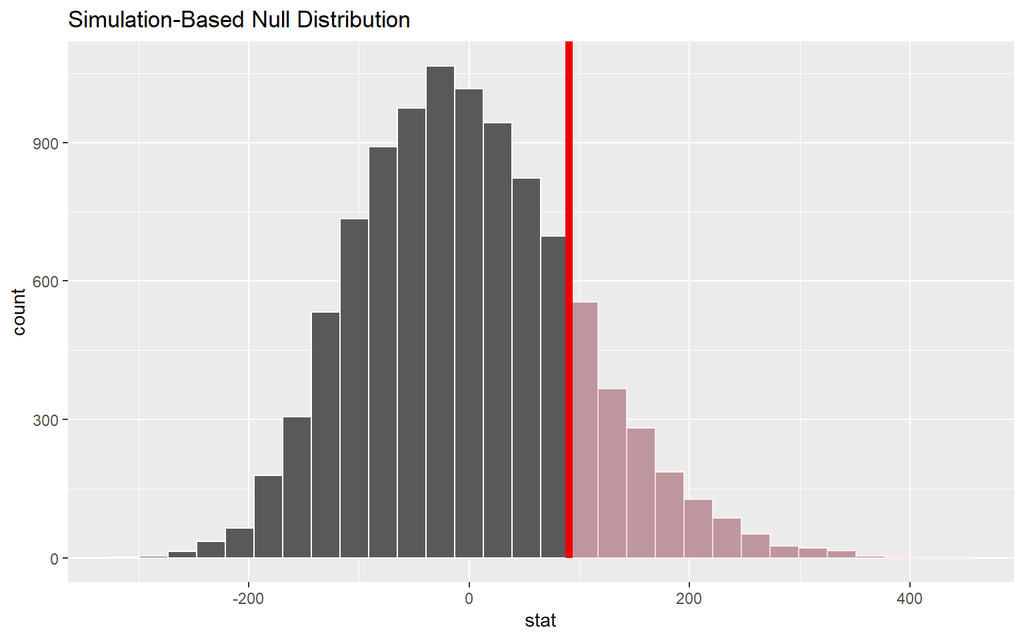

```r
null_dist <- poker %>%
  specify(response = winnings) %>%
  hypothesize(null = "point", mu = 0) %>%
  generate(reps = 10000, type = "bootstrap") %>%
  calculate(stat = "mean")

null_dist %>% visualize(bins = 30) +
  shade_p_value(obs_stat = x_bar, direction = "greater")
```

```r
null_dist %>%
  get_p_value(obs_stat = x_bar, direction = "greater")
```

```
## # A tibble: 1 × 1
##   p_value
##     <dbl>
## 1   0.175
```

Let’s see what we get from the t-statistic, and compute a null distribution based on t as well:

```r
t <- poker %>%
  specify(response = winnings) %>%
  calculate(stat = "t", mu = 0)
t
```

```
## Response: winnings (numeric)
## # A tibble: 1 × 1
##    stat
##   <dbl>
## 1 0.905
```

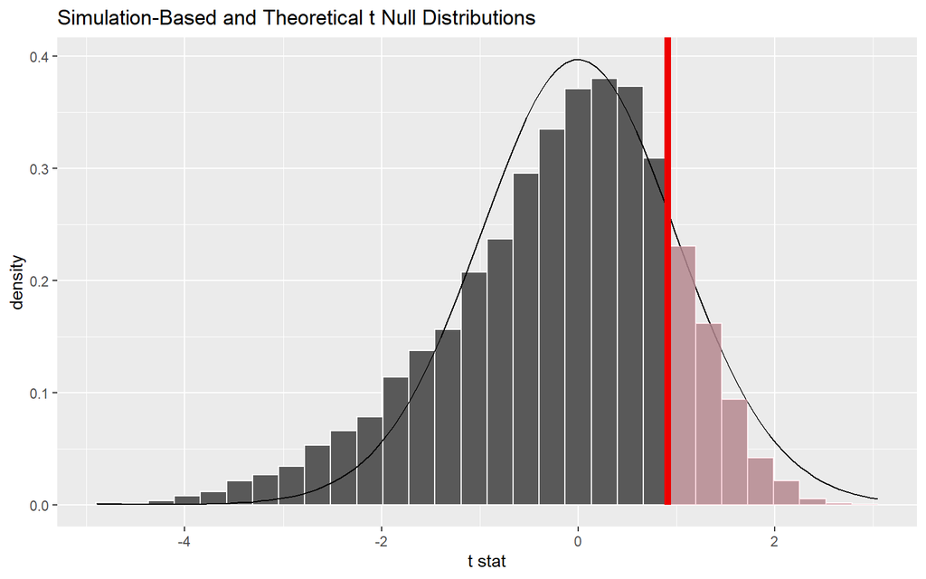

```r
null_dist <- poker %>%
  specify(response = winnings) %>%
  hypothesize(null = "point", mu = 0) %>%
  generate(reps = 10000, type = "bootstrap") %>%
  calculate(stat = "t")

null_dist %>% visualize(method = "both",bins = 30) +
  shade_p_value(obs_stat = t, direction = "greater")
```

```r
null_dist %>%
  get_p_value(obs_stat = t, direction = "greater")
```

```
## # A tibble: 1 × 1
##   p_value
##     <dbl>
## 1   0.154
```

What do you notice/wonder?

## T-test for paired data

Take a look at the `textbooks` data set in `openintro`. We are interested in the question, “Are textbooks more expensive at the UCLA bookstore than they are at Amazon?”

```r
x_bar <- textbooks %>%
  specify(response = diff) %>%
  calculate(stat = "mean")
x_bar
```

```
## Response: diff (numeric)
## # A tibble: 1 × 1
##    stat
##   <dbl>
## 1  12.8
```

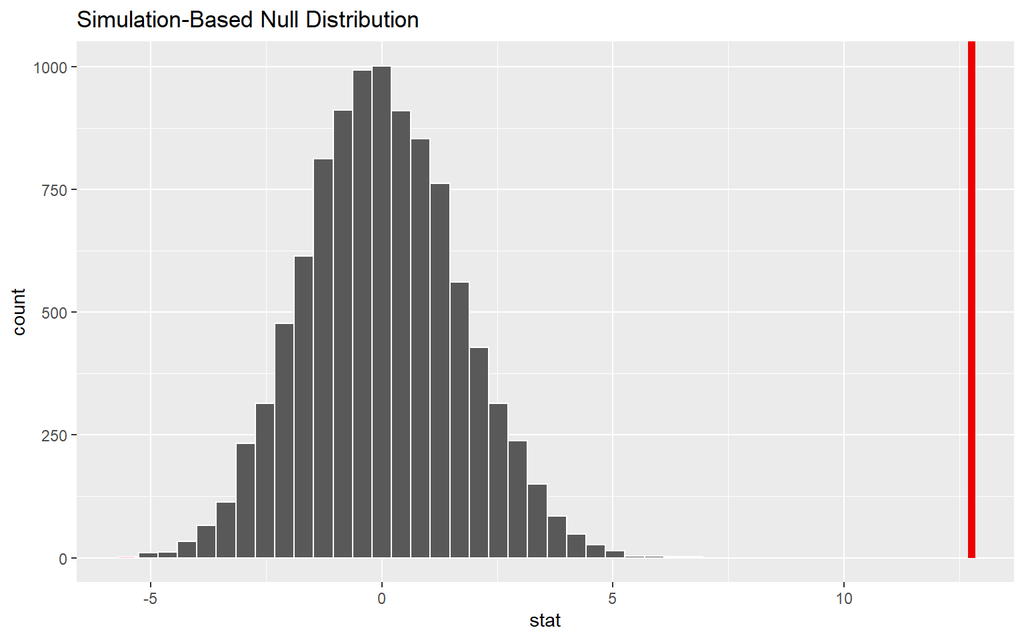

```r
null_dist <- textbooks %>%
  specify(response = diff) %>%
  hypothesize(null = "point", mu = 0) %>%
  generate(reps = 10000, type = "bootstrap") %>%
  calculate(stat = "mean")

null_dist %>% visualise(bins = 30)+
  shade_p_value(obs_stat = x_bar, direction = "two-sided")
```

```r
null_dist %>% get_p_value(obs_stat = x_bar, direction = "two-sided")
```

```
## # A tibble: 1 × 1
##   p_value
##     <dbl>
## 1       0
```

## Difference in means

Look at the `ncbirths` data set in the `openintro` package. View the data and help file to get a sense of what this data set contains. We are interested in the question, “Is the average weight of babies born to mothers who smoke different than that of babies born to mothers who do not?”

Before trying to run any analysis, calculate the mean weight for each group, then create a set of stacked boxplots for the weights of each group.

Now, we can use the `infer` package to run tests similar to the above: The big difference is that we will have both a response variable *and* an explanatory variable. Let’s start with a confidence interval for the *mean difference between the groups*:

```r
ncbirths <- ncbirths %>%
  drop_na(weight, habit)

ncb_d_hat <- ncbirths %>%
  specify(response = weight, explanatory = habit) %>%
  calculate(stat = "diff in means", order = c("smoker", "nonsmoker"))
ncb_d_hat
```

```
## Response: weight (numeric)
## Explanatory: habit (factor)
## # A tibble: 1 × 1
##     stat
##    <dbl>
## 1 -0.316
```

```r
### Bootstrap Conf. Interval

ncb_boot_dist_d_hat <- ncbirths %>%
  specify(response = weight, explanatory = habit) %>%
  generate(reps = 10000, type = "bootstrap") %>%
  calculate(stat = "diff in means", order = c("smoker", "nonsmoker"))

ncb_percentile_ci <- get_ci(ncb_boot_dist_d_hat, level = 0.95)
ncb_percentile_ci
```

```
## # A tibble: 1 × 2
##   lower_ci upper_ci
##      <dbl>    <dbl>
## 1   -0.585  -0.0589
```

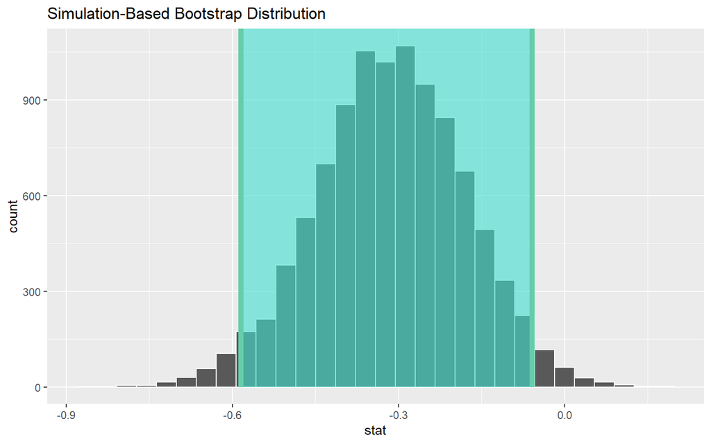

```r
ncb_boot_dist_d_hat %>% visualize(bins = 30) +
  shade_confidence_interval(endpoints = ncb_percentile_ci)
```

Now, we can calculate the t statistic, to see how unusual this difference is. Here we want to find the t-score of the difference between the groups, to see if it is different from 0. The t-statistic is the mean of the difference between the two groups, minus 0 (the null hypothesis is that the difference is 0), divided by the standard error, where:

$$SE = \sqrt{\frac{s_1^2}{n_1}+\frac{s_2^2}{n_2}}$$

```r
ncb_t_hat <- ncbirths %>%
  specify(response = weight, explanatory = habit) %>%
  calculate(stat = "t", order = c("smoker", "nonsmoker"))
ncb_t_hat
```

```
## Response: weight (numeric)
## Explanatory: habit (factor)
## # A tibble: 1 × 1
##    stat
##   <dbl>
## 1 -2.36
```

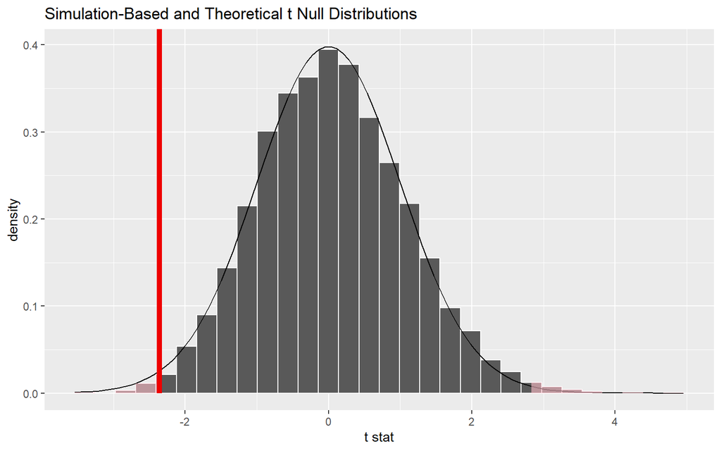

```r
ncb_null_dist_t <- ncbirths %>%
  specify(response = weight, explanatory = habit) %>%
  hypothesise(null = "independence") %>%
  generate(reps = 10000, type = "permute") %>%
  calculate(stat = "t", order = c("smoker", "nonsmoker"))

ncb_null_dist_t %>% visualise(bins = 30, method = "both") +
  shade_p_value(obs_stat = ncb_t_hat, direction = "two-sided")
```

```r
ncb_null_dist_t %>%
  get_p_value(obs_stat = ncb_t_hat, direction = "two-sided")
```

```
## # A tibble: 1 × 1
##   p_value
##     <dbl>
## 1  0.0104
```

## GSS Example

Here’s another possible question: are unemployed/laid off workers younger, on average, than full-time workers? We can calculate a *difference in means* for these groups, and determine if the difference is significant:

```r
gss_data <- gss_data %>%
  drop_na(age)

gss_data %>%
  group_by(wrkstat) %>%
  summarise(mean_age = mean(age))
```

```
## # A tibble: 9 × 2
##   wrkstat          mean_age
##   <fct>               <dbl>
## 1 working fulltime     42.9
## 2 working parttime     46.2
## 3 temp not working     47
## 4 unempl, laid off     39.8
## 5 retired              72.0
## 6 school               26.7
## 7 keeping house        47.1
## 8 other                56.8
## 9 <NA>                 56.5
```

```r
gss_data %>% filter(wrkstat == "working fulltime") %>%
  summarize(mean_age = mean(age))
```

```
## # A tibble: 1 × 1
##   mean_age
##      <dbl>
## 1     42.9
```

```r
gss_data %>% filter(wrkstat == "unempl, laid off") %>%
  summarize(mean_age = mean(age))
```

```
## # A tibble: 1 × 1
##   mean_age
##      <dbl>
## 1     39.8
```

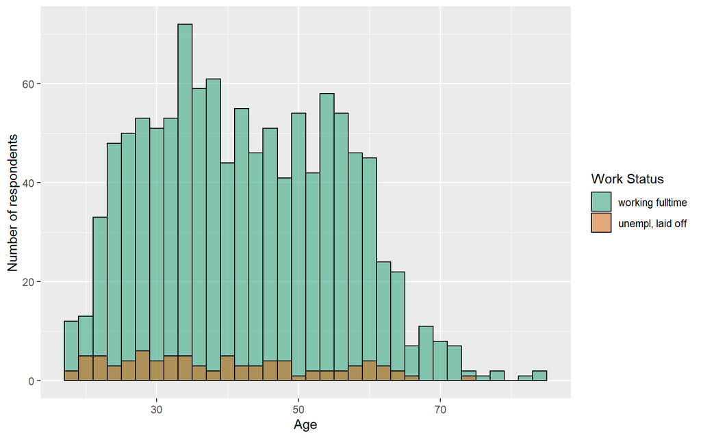

```r
gss_data %>% filter(wrkstat == "working fulltime" |
                  wrkstat == "unempl, laid off") %>%
  ggplot(aes(x = age)) +
  geom_histogram(aes(fill = wrkstat),
                 color = "black",
                 binwidth = 2,
                 alpha = 0.5,
                 position = "identity") +
  scale_fill_brewer(palette = "Dark2") +
  labs(
    x = "Age",
    y = "Number of respondents",
    fill = "Work Status"
  )
```

Using `infer`:

```r
gss_data_twogroups <- gss_data %>%
  filter(wrkstat == "working fulltime" |
         wrkstat == "unempl, laid off") %>%
  droplevels()

table(gss_data_twogroups$wrkstat)
```

```
##
## working fulltime unempl, laid off
##             1128               84
```

```r
gss_d_hat <- gss_data_twogroups %>%
  specify(response = age, explanatory = wrkstat) %>%
  calculate(stat = "diff in means")
gss_d_hat
```

```
## Response: age (numeric)
## Explanatory: wrkstat (factor)
## # A tibble: 1 × 1
##    stat
##   <dbl>
## 1  3.14
```

```r
### Bootstrap Conf. Interval

gss_boot_dist_d_hat <- gss_data_twogroups %>%
  specify(response = age, explanatory = wrkstat) %>%
  generate(reps = 10000, type = "bootstrap") %>%
  calculate(stat = "diff in means")

gss_percentile_ci <- get_ci(gss_boot_dist_d_hat, level = 0.95)
gss_percentile_ci
```

```
## # A tibble: 1 × 2
##   lower_ci upper_ci
##      <dbl>    <dbl>
## 1  -0.0506     6.26
```

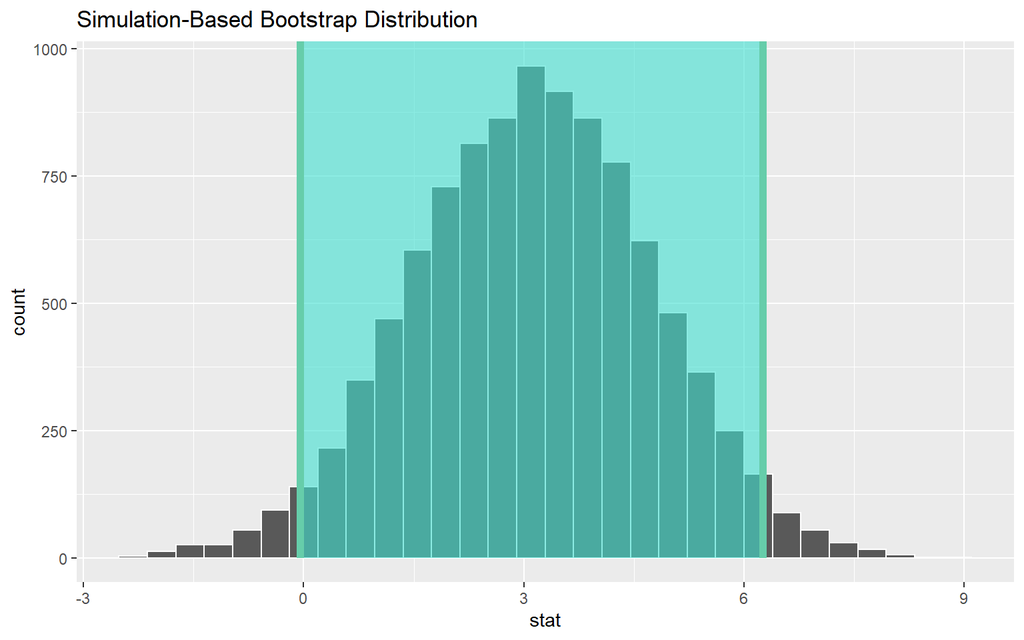

```r
gss_boot_dist_d_hat %>% visualize(bins = 30) +
  shade_confidence_interval(endpoints = gss_percentile_ci)
```

```r
### T-test:

gss_t_hat <- gss_data_twogroups %>%
  specify(response = age, explanatory = wrkstat) %>%
  calculate(stat = "t")
gss_t_hat
```

```
## Response: age (numeric)
## Explanatory: wrkstat (factor)
## # A tibble: 1 × 1
##    stat
##   <dbl>
## 1  1.95
```

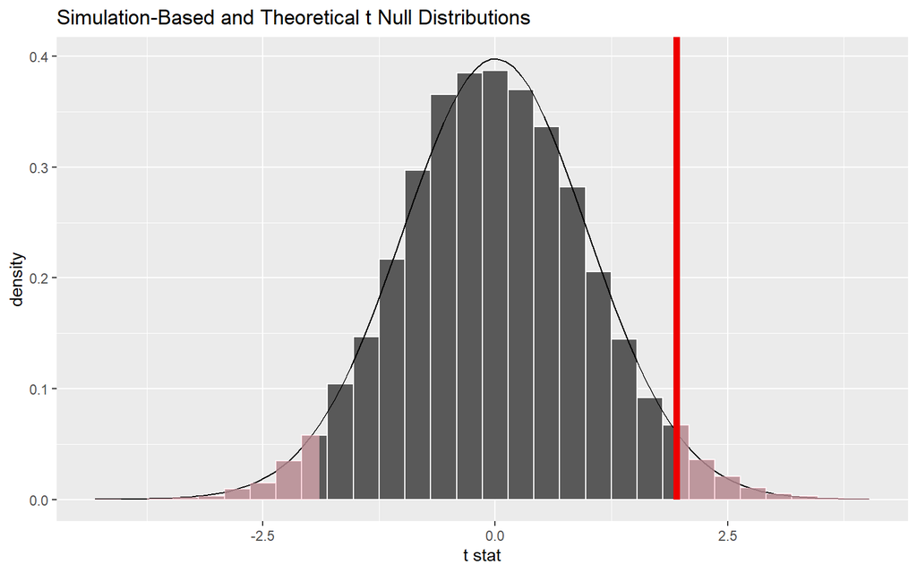

```r
null_dist_t <- gss_data_twogroups %>%
  specify(response = age, explanatory = wrkstat) %>%
  hypothesise(null = "independence") %>%
  generate(reps = 10000, type = "permute") %>%
  calculate(stat = "t")

null_dist_t %>% visualise(bins = 30, method = "both") +
  shade_p_value(obs_stat = gss_t_hat, direction = "two-sided")
```

```r
null_dist_t %>%
  get_p_value(obs_stat = gss_t_hat, direction = "two-sided")
```

```
## # A tibble: 1 × 1
##   p_value
##     <dbl>
## 1  0.0572
```

## Analysis of Variance (ANOVA)

Look again at the GSS data on work status and age. Rather than examine each pair of groups, we want to test the null hypothesis of whther these two variables are independent across all the groups. In order ot examine this, we’ll conduct an Analysis of Variance, also known as an ANOVA or F-test.

Both MSE and MSG are complicated to calculate, but roughly speaking, MSG is the variance *between* group means, where MSE is the variance *within* groups.

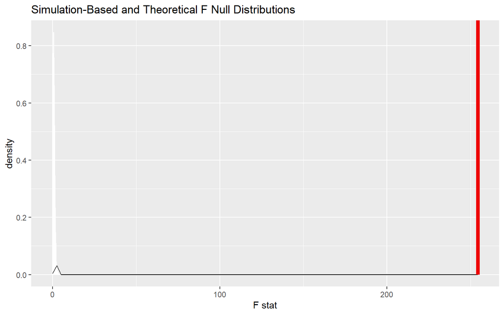

```r
gss_F_stat <- gss_data %>%
  specify(response = age, explanatory = wrkstat) %>%
  calculate(stat = "F")

gss_F_null_dist<- gss_data %>%
  specify(response = age, explanatory = wrkstat) %>%
  hypothesise(null = "independence") %>%
  generate(reps = 10000, type = "permute") %>%
  calculate(stat = "F")

gss_F_null_dist %>% visualise(bins = 30, method = "both") +
  shade_p_value(obs_stat = gss_F_stat, direction = "greater")
```

```r
gss_F_null_dist %>%
  get_p_value(obs_stat = gss_F_stat, direction = "greater")
```

```
## # A tibble: 1 × 1
##   p_value
##     <dbl>
## 1       0
```

You can run an ANOVA in R using the code:

```r
gss_data %>%
    group_by(wrkstat) %>%
    summarise(mean_age = mean(age))
```

```
## # A tibble: 9 × 2
##   wrkstat          mean_age
##   <fct>               <dbl>
## 1 working fulltime     42.9
## 2 working parttime     46.2
## 3 temp not working     47
## 4 unempl, laid off     39.8
## 5 retired              72.0
## 6 school               26.7
## 7 keeping house        47.1
## 8 other                56.8
## 9 <NA>                 56.5
```

```r
gss_model <- lm(age ~ wrkstat, data = gss_data)
gss_model
```

```
##
## Call:
## lm(formula = age ~ wrkstat, data = gss_data)
##
## Coefficients:
##             (Intercept)  wrkstatworking parttime  wrkstattemp not working
##                  42.945                    3.280                    4.055
## wrkstatunempl, laid off           wrkstatretired            wrkstatschool
##                  -3.136                   29.064                  -16.278
##    wrkstatkeeping house             wrkstatother
##                   4.154                   13.805
```

```r
anova(gss_model)
```

```
## Analysis of Variance Table
##
## Response: age
##             Df Sum Sq Mean Sq F value                Pr(>F)
## wrkstat      7 330394   47199  254.26 < 0.00000000000000022 ***
## Residuals 2331 432705     186
## ---
## Signif. codes:  0 '***' 0.001 '**' 0.01 '*' 0.05 '.' 0.1 ' ' 1
```

Try running similar tests with the `classdata` set from `openintro`.